**Instructor copy.** Executed notebook with all results shown, including the "after your attempt" cells. Projector/offline fallback; learners should use the notebook itself.

# f4d · Find the missing state: column generation (advanced steps 13–14)

**In plain words.** The menu of step 10 was too coarse: the curves dip below its line between the dots. Instead of listing every possible state, ask one question again and again: is anything below my line? Add the deepest state, solve the menu again, and repeat. Each round also gives a ceiling and a floor, so you always know how far from the truth you can still be.

**Learning goals.** After this notebook you can

1. start the search from a menu, from the two pure ends, and recognise a start that cannot work;
2. do one round by hand: add a state, solve, draw the new line;
3. write the whole loop in a few lines and compare it with the course helper;
4. report a ceiling, a floor (raw and best so far) and the remaining uncertainty after every round, also for a run you stop early;
5. (dive deeper) say what pycalphad does in the same three stages, and why its sampled grid gets sparse when the number of elements grows.

**What you need.** Steps 10–14 of the course, or notebook f4c, or at least these cards: reading a line, floor and ceiling, reduced cost, column generation, how ceiling, floor and remaining uncertainty fit together.

| Section | What | Track | Time |
| --- | --- | --- | --- |
| 1 | Where the search starts | main | 10 min |
| 2 | One round by hand | main | 15 min |
| 3 | The deepest dip has a formula | main | 10 min |
| 4 | The loop | main | 15 min |
| 5 | Ceiling and floor in every round | main | 10 min |
| 6 | A run stopped early | main | 5 min |
| 7 | What a CALPHAD program does | dive deeper | 15 min |
| 8 | Exercises | both | 25 min |

**Coming from materials.** Every round asks "which composition, at the current prices, would lower the energy most?": the largest driving force, asked for every composition at once. The answer moves the line towards the common tangent of step 03.

**Coming from operations research.** This is column generation with a restricted master (the menu LP), exact pricing (the ideal phase models have a closed form) and the Lagrangian bound with one convexity row. New is the physical meaning of each piece.

**How to work.** Run the cells from top to bottom. In each "Your turn" cell, replace `None` with your value and run it: `check` says whether you match, without showing the answer. Cells marked *After your attempt* hold worked solutions.

```python
# Setup: run this cell first. Locally it finds the course folder; in Colab it
# downloads the tested course release and the locked package versions.
# In Colab, the first run then restarts the session on purpose and Colab reports
# a crash: that is expected. Run this cell again, then the rest of the notebook.
RELEASE = "main"
import os, pathlib, subprocess, sys, time
ROOT = next((p for p in (pathlib.Path.cwd(), *pathlib.Path.cwd().parents)
             if (p / "pyproject.toml").is_file() and (p / "course").is_dir()), None)
if ROOT is None and "google.colab" in sys.modules:
    ROOT = pathlib.Path("/content/CalphadIntro")
    if not ROOT.is_dir():
        clone = ["git", "clone", "-q", "--depth", "1", "--branch", RELEASE,
                 "https://github.com/ukerzel/CalphadIntro.git", str(ROOT)]
        git = dict(os.environ, GIT_TERMINAL_PROMPT="0")
        if subprocess.run(clone, env=git, capture_output=True).returncode:
            raise SystemExit(f"Could not download course release {RELEASE}: check the internet "
                             "connection and run this cell again.")
    if not (ROOT / ".colab-ready").exists():
        if subprocess.run([sys.executable, "-m", "pip", "install", "-q", "-r",
                           str(ROOT / "notebooks" / "requirements-colab.txt")]).returncode:
            raise SystemExit("Installing the course packages failed; run this cell again.")
        (ROOT / ".colab-ready").touch()
        # Colab has already loaded its own numpy; a fresh session is needed to use the installed versions.
        print("Installed the course's package versions. Colab now restarts this session and"
              " reports a crash; that is expected. When it has reconnected, run this cell again"
              " (it will not install twice), then the rest of the notebook.", flush=True)
        time.sleep(3)
        os.kill(os.getpid(), 9)
if ROOT is None:
    raise SystemExit("Open this notebook from the course folder (poetry run jupyter lab) or in Colab.")
os.chdir(ROOT)
sys.path.insert(0, str(ROOT))
from notebooks.helpers import check, confirm, database, show_versions
show_versions(RELEASE)
```

```
Course release main · Python 3.12.14
  numpy       2.5.3
  scipy       1.18.1
  matplotlib  3.11.2
  xarray      2026.7.0
  pycalphad   0.11.2
```

```
True
```

## 0. Numbers you may change, and the tools

Leave these as they are for the first run: the "Your turn" checks expect them. Later, change one number at a time and rerun everything below it.

- `T`: the temperature in K (the melting lens of step 03 part C);
- `z`: the overall B atom fraction of the sample;
- `MENU_X`: the dots of the starting menu, the same for both phase models;
- `TOL`: stop when the remaining uncertainty is at most this, J/mol atoms.

```python
T = 1400.0                          # K
z = 0.40                            # overall B atom fraction of the sample
MENU_X = [0.1, 0.3, 0.5, 0.7, 0.9]  # the step 10 menu
TOL = 1e-6                          # J/mol atoms
DEFAULTS = (T, z, MENU_X) == (1400.0, 0.40, [0.1, 0.3, 0.5, 0.7, 0.9])   # are these the page's numbers?
```

`day3_core` is the small library behind every number on the advanced steps of the website. Here we use its two lens phase models (`lens_models`), its menu solver (`solve_master`, the linear programme of notebook f4c) and its pricing step. Colours follow the website: SOLID blue, LIQUID orange.

```python
import math
import numpy as np
import matplotlib.pyplot as plt
from course.self_study import day3_core as d

SOLID_C, LIQUID_C, LINE_C = "#2445c4", "#cf4418", "#8f6400"   # the website's colours
COLOUR = {"SOLID": SOLID_C, "LIQUID": LIQUID_C}
models = d.lens_models(T)            # {'SOLID': model, 'LIQUID': model}; each has .g(x)
```

A picture we redraw after every stage: the **gap curve**, each phase model's energy minus the current line, with the menu's states as dots. A state below zero would lower the energy if it were added. The function only draws; give it the line and the states.

```python
def draw_gap(mu_A, d_mu, states, title, window=(0.2, 0.6), ylim=None):
    xs = np.linspace(window[0], window[1], 801)
    fig, ax = plt.subplots(figsize=(7, 3.2))
    for phase, model in models.items():
        ax.plot(xs, model.g(xs) - (mu_A + d_mu * xs), color=COLOUR[phase], label=phase)
    for s in states:
        ax.plot(s.x, s.g - (mu_A + d_mu * s.x), "o", color=COLOUR[s.phase])
    ax.axhline(0, color="black", lw=0.8)
    ax.set(xlim=window, ylim=ylim, xlabel="B atom fraction x", ylabel="gap (J/mol atoms)", title=title)
    ax.legend(); plt.show()
```

## 1. Where the search starts (main track, 10 min)

Column generation needs a first menu, the *seed*, that can make the sample at all: at least one dot left of $z$ and one right of it (or one exactly at $z$). Our first seed is the menu of step 10.

```python
menu = d.menu_states(models, MENU_X)        # list of states: phase, x and g
master = d.solve_master(menu, z)
print(f"ceiling G_up = {master.G_up:.2f}; line mu_A = {master.mu_A:.1f}, d_mu = {master.d_mu:.1f}")
if DEFAULTS:   # lesson values exist only for the page's own numbers
    confirm(master.G_up, -20429.542431, "The step 10 menu's cheapest mixture", tol=1e-5)
```

```
ceiling G_up = -20429.54; line mu_A = -19873.9, d_mu = -1389.0
✓ The step 10 menu's cheapest mixture reproduces the lesson value.
```

A second seed needs no menu at all: the two pure ends, $x=0$ and $x=1$. At the ends the mixing term is zero, so the energies are finite (the helper uses $0\ln0=0$). The pure ends can make any $z$ by the lever rule.

```python
ends = d.menu_states(models, [0.0, 1.0])
for s in ends:
    print(f"{s.phase:6s} x = {s.x:.0f}: g = {s.g:.1f}")
print(f"ceiling from the pure ends: {d.solve_master(ends, z).G_up:.2f}")
```

```
SOLID  x = 0: g = -13000.0
SOLID  x = 1: g = -12000.0
LIQUID x = 0: g = -15400.0
LIQUID x = 1: g = -8000.0
ceiling from the pure ends: -14040.00
```

**Predict first:** what happens if every dot of the seed lies right of $z$? The solver should refuse: no non-negative amounts can make $z=0.40$ from dots at 0.6 and 0.8. The next cell catches the solver's message.

```python
bad = d.menu_states(models, [0.6, 0.8])
try:
    d.solve_master(bad, z)
except ValueError as message:
    print("the solver says:", message)
```

```
the solver says: the menu cannot make z = 0.4: The problem is infeasible. (HiGHS Status 8: model_status is Infeasible; primal_status is None)
```

The fix is to add a dot on the other side of $z$; any one will do. Pure A ($x=0$) is always available.

```python
fixed = bad + d.menu_states(models, [0.0])
print(f"with pure A added: ceiling {d.solve_master(fixed, z).G_up:.2f}")
```

```
with pure A added: ceiling -18622.71
```

## 2. One round by hand (main track, 15 min)

Step 12 found the deepest dip of the step 10 line: SOLID near $x=0.4489$. We add that state, printed as $x=0.44887$. Its energy comes from the model, rounded to two decimals as on step 13.

```python
x_new = 0.44887
g_new = round(float(models["SOLID"].g(x_new)), 2)
g_liq = round(float(models["LIQUID"].g(0.3)), 2)       # the LIQUID dot that stays in use
print(f"new SOLID state: x = {x_new}, g = {g_new}; LIQUID x = 0.3, g = {g_liq}")
```

```
new SOLID state: x = 0.44887, g = -20558.6; LIQUID x = 0.3, g = -20290.64
```

**Predict first:** with the new state on the menu, which two states make $z=0.40$ cheapest? (Step 13 says: LIQUID 0.3 and the new SOLID.) Work the lever rule, the energy and the line yourself before running the next cells.

### Your turn: round 1 by hand

1. The amount of the new SOLID state, $f_S=(z-0.3)/(x_{\text{new}}-0.3)$.
2. The new ceiling, $f_L\,g_L+f_S\,g_S$.
3. The new slope $\Delta\mu$ of the line through the two used states.

```python
f_S = None          # mol atoms per mol sample
G_up_1 = None       # J/mol atoms
d_mu_1 = None       # J/mol
check(f_S, "f4d_f_solid_round1")
check(G_up_1, "f4d_ceiling_round1")
check(d_mu_1, "f4d_d_mu_round1")
```

```
f4d_f_solid_round1: not attempted yet. Replace None with your value and run the cell again.
f4d_ceiling_round1: not attempted yet. Replace None with your value and run the cell again.
f4d_d_mu_round1: not attempted yet. Replace None with your value and run the cell again.
```

```python
#@title After your attempt: round 1 by hand
f_S_hand = (z - 0.3) / (x_new - 0.3)
G_hand = (1 - f_S_hand) * g_liq + f_S_hand * g_new
slope = (g_new - g_liq) / (x_new - 0.3)
print(f"f_S = {f_S_hand:.3f}, ceiling = {G_hand:.2f}, d_mu = {slope:.1f}, mu_A = {g_liq - slope * 0.3:.1f}")
```

```
f_S = 0.672, ceiling = -20470.64, d_mu = -1800.0, mu_A = -19750.7
```

Now let the solver do the same round and compare. The helper's state uses the unrounded energy, so agreement to about 0.1 J/mol atoms is what to expect.

```python
round1 = d.solve_master(menu + [d.State("SOLID", x_new, float(models["SOLID"].g(x_new)))], z)
for state, amount in round1.used():
    print(f"uses {state.phase} at x = {state.x}: f = {amount:.3f}")
print(f"ceiling {round1.G_up:.2f}; mu_A = {round1.mu_A:.1f}, d_mu = {round1.d_mu:.1f}")
if DEFAULTS:   # the hand round uses the page's numbers
    assert abs(round1.G_up - G_hand) < 0.1, "hand and solver disagree by more than 0.1 J/mol atoms"
```

```
uses LIQUID at x = 0.3: f = 0.328
uses SOLID at x = 0.44887: f = 0.672
ceiling -20470.64; mu_A = -19750.7, d_mu = -1800.0
```

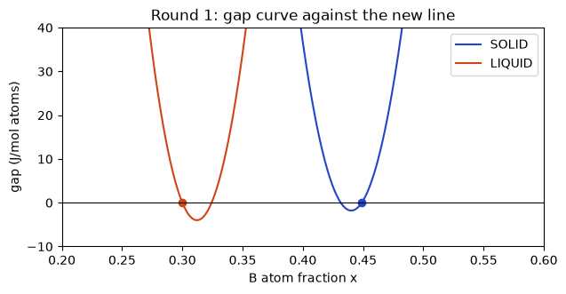

```python
draw_gap(round1.mu_A, round1.d_mu, round1.states, "Round 1: gap curve against the new line", ylim=(-10, 40))
```

The added state now sits on the line (gap zero). The line has tilted, and the deepest dip has moved to the LIQUID side, near 0.312: much shallower than before, but still below zero.

## 3. The deepest dip has a formula (main track, 10 min)

For an ideal phase model the gap curve is

$$\mathrm{gap}(x)=a+b\,x+RT\,[x\ln x+(1-x)\ln(1-x)]-\mu_A-\Delta\mu\,x ,$$

where $a+b\,x$ is the straight line between the model's pure ends. It bends up everywhere, so its lowest point is where its slope is zero: $b-\Delta\mu+RT\ln\frac{x}{1-x}=0$. Solving for $x$ gives

$$x^*=\frac{1}{1+e^{-(\Delta\mu-b)/RT}} .$$

No search is needed: one line of arithmetic per phase model gives the deepest state. (Each model stores its $a$ and $b$.)

```python
def deepest_state(model, mu_A, d_mu):
    x = 1 / (1 + math.exp(-(d_mu - model.b) / (d.R * model.T)))   # where the gap curve is flattest
    return x, float(model.g(x)) - (mu_A + d_mu * x)                 # the state and its gap

for phase, model in models.items():
    x, gap = deepest_state(model, master.mu_A, master.d_mu)
    print(f"{phase:6s}: deepest at x = {x:.5f}, gap {gap:.3f} J/mol atoms")
```

```
SOLID : deepest at x = 0.44887, gap -61.180 J/mol atoms
LIQUID: deepest at x = 0.31972, gap -10.527 J/mol atoms
```

Check the formula against the helper's pricing step and against a fine grid. A grid can only confirm it from above; the formula is the guarantee.

```python
for phase, model in models.items():
    x, gap = deepest_state(model, master.mu_A, master.d_mu)
    dip = d.price_ideal(model, master.mu_A, master.d_mu)
    xs = np.linspace(0.001, 0.999, 9999)
    grid_low = (model.g(xs) - (master.mu_A + master.d_mu * xs)).min()
    assert abs(x - dip.x) < 1e-12 and abs(gap - dip.depth) < 1e-9, f"{phase}: formula and helper differ"
    assert grid_low >= gap - 1e-9, f"{phase}: the grid went below the formula's minimum"
print("formula = helper, and no grid point lies below it")
```

```
formula = helper, and no grid point lies below it
```

### Your turn: the deepest SOLID state of the step 10 line

Use the formula with the step 10 line ($\Delta\mu=-1389.0$), $b=1000$ for SOLID and $RT=11640.3$ J/mol. Give $x^*$ to four decimals.

```python
x_star = None   # B atom fraction
check(x_star, "f4d_closed_form_x")
```

```
f4d_closed_form_x: not attempted yet. Replace None with your value and run the cell again.
```

## 4. The loop (main track, 15 min)

Now the whole method in a few lines: solve the menu, read the line, find the deepest state of each phase model, stop if none lies below the line, otherwise add the deepest one and go round again.

**Predict first:** how many rounds until the deepest dip is smaller than 0.003 J/mol atoms?

```python
states = list(menu)
for k in range(10):
    m = d.solve_master(states, z)                                 # master: menu -> line
    found = [(deepest_state(mod, m.mu_A, m.d_mu), p) for p, mod in models.items()]
    (x, gap), phase = min(found, key=lambda item: item[0][1])     # pricer: the deepest dip
    print(f"round {k}: ceiling {m.G_up:.4f}, deepest dip {gap:.4f} ({phase} at {x:.4f})")
    if gap > -TOL:
        break                                                     # nothing worth adding
    states.append(d.State(phase, x, float(models[phase].g(x))))   # add it, go round again
```

```
round 0: ceiling -20429.5424, deepest dip -61.1804 (SOLID at 0.4489)
```

```
round 1: ceiling -20470.6388, deepest dip -3.9931 (LIQUID at 0.3121)
round 2: ceiling -20472.0655, deepest dip -1.5470 (SOLID at 0.4408)
round 3: ceiling -20473.1223, deepest dip -0.0027 (LIQUID at 0.3124)
round 4: ceiling -20473.1232, deepest dip -0.0015 (SOLID at 0.4405)
round 5: ceiling -20473.1242, deepest dip -0.0000 (SOLID at 0.4405)
```

The course helper `column_generation` does the same, and also keeps the floors (section 5). The two must agree round by round.

```python
history = d.column_generation(models, menu, z, tol=1e-9, max_iter=40)
for it in history:
    print(f"round {it.k}: ceiling {it.master.G_up:.4f}, deepest dip {it.best.depth:.4f}")
if DEFAULTS:   # lesson values exist only for the page's own numbers
    confirm(history[3].best.depth, -0.002719896, "The deepest dip in round 3", tol=1e-8)
```

```
round 0: ceiling -20429.5424, deepest dip -61.1804
round 1: ceiling -20470.6388, deepest dip -3.9931
round 2: ceiling -20472.0655, deepest dip -1.5470
round 3: ceiling -20473.1223, deepest dip -0.0027
round 4: ceiling -20473.1232, deepest dip -0.0015
round 5: ceiling -20473.1242, deepest dip -0.0000
round 6: ceiling -20473.1242, deepest dip -0.0000
✓ The deepest dip in round 3 reproduces the lesson value.
```

After the first added state, two more additions bring the deepest dip to 0.0027 J/mol atoms, and a fourth to 0.0015. Redraw the gap curve after each round. The dips get too small to see on one scale, so each picture zooms in to its own dip.

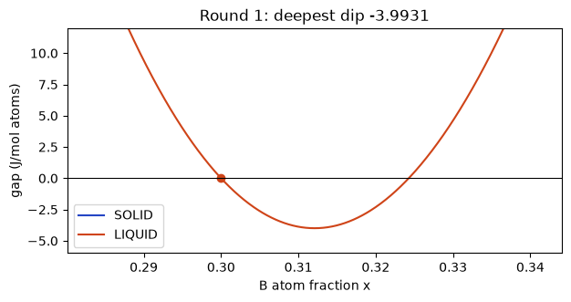

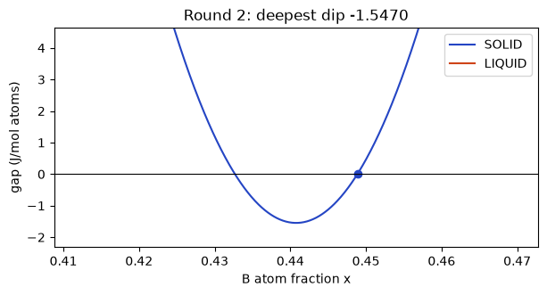

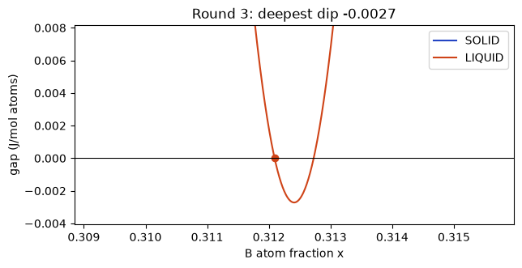

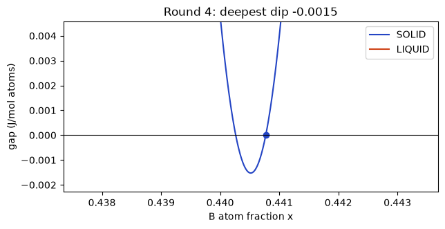

```python
for it in history[1:5]:
    w = abs(it.best.depth)
    draw_gap(it.master.mu_A, it.master.d_mu, it.master.states, f"Round {it.k}: deepest dip {it.best.depth:.4f}",
             window=(it.best.x - 0.03 * min(1, w) ** 0.5 - 0.002, it.best.x + 0.03 * min(1, w) ** 0.5 + 0.002), ylim=(-1.5 * w, 3 * w))
```

The used states approach the true compositions, liquid 0.312 and solid 0.441, and the line approaches the common tangent of step 03. Two states of the same phase model can be used together for a while (twin dots): they stand for one phase between them.

```python
last = history[-1].master
for state, amount in last.used():
    print(f"{state.phase:6s} x = {state.x:.5f}: f = {amount:.4f}")
if DEFAULTS:   # lesson values exist only for the page's own numbers
    confirm(last.G_up, -20473.124218, "The converged ceiling (the lens answer of step 03)", tol=1e-5)
```

```
LIQUID x = 0.31241: f = 0.3163
SOLID  x = 0.44052: f = 0.6837
✓ The converged ceiling (the lens answer of step 03) reproduces the lesson value.
```

### Your turn: read the rounds

1. The remaining uncertainty after round 3 (the deepest dip of round 3, as a positive number).
2. How many states are added *after the first one* until the deepest dip is below 0.003 J/mol atoms?

```python
remaining_3 = None      # J/mol atoms, positive
more_states = None      # a whole number
check(remaining_3, "f4d_remaining_round3")
check(more_states, "f4d_more_states")
```

```
f4d_remaining_round3: not attempted yet. Replace None with your value and run the cell again.
f4d_more_states: not attempted yet. Replace None with your value and run the cell again.
```

## 5. Ceiling and floor in every round (main track, 10 min)

Every round gives two numbers that bracket the truth:

- the **ceiling** `G_up`: the menu's cheapest mixture, a real mixture;
- the **floor** `G_low`: the line at $z$ lowered by the deepest dip of the whole curve, $\mu_A+\Delta\mu\,z+\min(0,\text{dip})$.

The ceiling never rises, because the menu only grows. The raw floor can fall from one round to the next, because the line moves; every raw floor is valid, so we keep the best (highest) one so far.

```python
print(" round   ceiling        raw floor      best floor     remaining")
for it in history:
    print(f"{it.k:5d}  {it.master.G_up:12.4f}  {it.G_low_raw:12.4f}  {it.G_low_best:12.4f}  {it.gap:12.6f}")
```

```
 round   ceiling        raw floor      best floor     remaining
    0   -20429.5424   -20490.7229   -20490.7229     61.180449
    1   -20470.6388   -20474.6319   -20474.6319      3.993105
    2   -20472.0655   -20473.6125   -20473.6125      1.546956
    3   -20473.1223   -20473.1250   -20473.1250      0.002720
    4   -20473.1232   -20473.1247   -20473.1247      0.001525
    5   -20473.1242   -20473.1242   -20473.1242      0.000000
    6   -20473.1242   -20473.1242   -20473.1242      0.000000
```

```python
ups = [it.master.G_up for it in history]
assert all(b <= a + 1e-9 for a, b in zip(ups, ups[1:])), "the ceiling rose: the menu lost a state?"
truth = history[-1].master.G_up
assert all(it.G_low_best <= truth + 1e-8 for it in history), "a floor lies above the answer"
print("ceilings never rise; every floor lies at or below the answer")
```

```
ceilings never rise; every floor lies at or below the answer
```

On a logarithmic axis the remaining uncertainty falls by orders of magnitude in a few rounds.

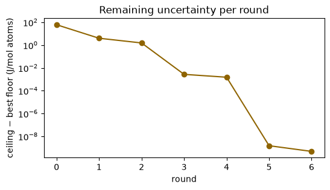

```python
rows = [it for it in history if it.gap > 0]
fig, ax = plt.subplots(figsize=(6, 3))
ax.semilogy([it.k for it in rows], [it.gap for it in rows], "o-", color=LINE_C)
ax.set(xlabel="round", ylabel="ceiling − best floor (J/mol atoms)", title="Remaining uncertainty per round")
plt.show()
```

**The floor can fall.** Start from the two pure ends instead. Watch the raw floor column: it goes down before it goes up. The best-so-far floor does not.

```python
from_ends = d.column_generation(models, ends, z, tol=1e-9, max_iter=40)
for it in from_ends[:6]:
    print(f"round {it.k}: raw floor {it.G_low_raw:11.2f}   best floor {it.G_low_best:11.2f}   ceiling {it.master.G_up:11.2f}")
print(f"... {len(from_ends)} rounds in all to a remaining uncertainty of 1e-9, ending at {from_ends[-1].master.G_up:.4f}")
```

```
round 0: raw floor   -20970.19   best floor   -20970.19   ceiling   -14040.00
round 1: raw floor   -21579.95   best floor   -20970.19   ceiling   -19067.67
round 2: raw floor   -20505.28   best floor   -20505.28   ceiling   -20132.13
round 3: raw floor   -20534.83   best floor   -20505.28   ceiling   -20362.24
round 4: raw floor   -20476.59   best floor   -20476.59   ceiling   -20464.10
round 5: raw floor   -20473.81   best floor   -20473.81   ceiling   -20472.72
... 10 rounds in all to a remaining uncertainty of 1e-9, ending at -20473.1242
```

## 6. A run stopped early (main track, 5 min)

A real program has a work limit. Stop after one round: what can you say? Not "this is the answer", but "the answer lies between this floor and this ceiling". If the gap between them is larger than you care about, the result is **unresolved**.

```python
short = d.column_generation(models, menu, z, tol=TOL, max_iter=1)
it = short[-1]
status = "converged" if it.gap <= TOL else "unresolved"
print(f"after {it.k} added state(s): {status}; floor {it.G_low_best:.2f} <= answer <= ceiling {it.master.G_up:.2f}")
print(f"remaining uncertainty {it.gap:.2f} J/mol atoms")
```

```
after 1 added state(s): unresolved; floor -20474.63 <= answer <= ceiling -20470.64
remaining uncertainty 3.99 J/mol atoms
```

### Your turn: the stopped run

What is the remaining uncertainty of the run stopped after one added state?

```python
remaining_stopped = None   # J/mol atoms
check(remaining_stopped, "f4d_unresolved_remaining")
```

```
f4d_unresolved_remaining: not attempted yet. Replace None with your value and run the cell again.
```

## 7. What a CALPHAD program does (dive deeper, 15 min)

pycalphad 0.11.2 finds an equilibrium in three stages, each with a name from the advanced steps:

| Stage in pycalphad | What it does | Name in the advanced steps |
| --- | --- | --- |
| grid LP | samples states of every phase and solves the menu LP over them | the menu and its line (steps 10–11) |
| continuous refinement | a Newton-type solver moves the compositions of the phases in use off the grid and returns new chemical potentials | adding a better state (step 13), done continuously |
| pricing the grid | checks every sampled state against the new line and adds the phase with the largest driving force, up to ten rounds | the pricing step, with the grid as the search set |

The next cell solves our lens with pycalphad from the same model written as a small database (the one step 03 part D uses) and compares the energy with the column-generation answer. It takes a few seconds.

```python
from pycalphad import Database, equilibrium, variables as v
from course.self_study.from_scratch_export import TDB      # the lens as a database text
eq = equilibrium(Database(TDB), ["A", "B"], ["SOLID", "LIQUID"], {v.T: T, v.P: 100000, v.N: 1, v.X("B"): z})
G_pycalphad = float(eq.GM.values.squeeze())
print(f"pycalphad {G_pycalphad:.6f}   column generation {truth:.6f}   difference {G_pycalphad - truth:.2e}")
assert abs(G_pycalphad - truth) < max(1e-4, history[-1].gap + 1e-6), "pycalphad and column generation disagree by more than the remaining uncertainty"
```

```
pycalphad -20473.124218   column generation -20473.124218   difference -4.77e-10
```

**Where the effort goes with many elements.** pycalphad's default sample for an equilibrium is 60 points per degree of freedom. For a phase with one sublattice and $C$ elements that is $60(C-1)$ interior points (plus the pure ends and lines between them). The space they must cover has $C-1$ dimensions, so the points per direction shrink fast.

```python
from pycalphad.core.utils import point_sample
for C in (2, 3, 5, 10):
    n = point_sample([C], pdof=60).shape[0]
    print(f"{C:2d} elements: {n:4d} interior points, about {n ** (1 / (C - 1)):5.1f} per direction")
```

```
 2 elements:   60 interior points, about  60.0 per direction
 3 elements:  120 interior points, about  11.0 per direction
 5 elements:  240 interior points, about   3.9 per direction
10 elements:  540 interior points, about   2.0 per direction
```

The binary edges stay well covered; the inside of a many-element phase does not. A valley between sparse points can be missed (step 10's coarse-grid miss in more dimensions), and a denser grid costs energy evaluations at every temperature. Searching for the deepest state by a formula or a branch-and-bound check, as in steps 13–16, is the other way out. No speed comparison is made here.

## 8. Exercises

**Materials flavour: run, change one number, explain.**

- Set `T = 1500.0` in section 0 and rerun. How do the final compositions and the number of rounds change? Compare with the lens of step 03 part C.
- Set `MENU_X = [0.3, 0.5]` and rerun. Does a smaller seed need more rounds?

**Optimisation flavour: complete a function.** Complete `one_round`: given the current list of states, solve the master, price both phase models with `deepest_state`, and return the new list of states (unchanged if nothing lies below the line by more than `TOL`).

```python
def one_round(states):
    """Master, pricer, add: one round of column generation."""
    return None   # replace with the new list of states

after = one_round(list(menu))
check(None if after is None else d.solve_master(after, z).G_up, "f4d_ceiling_round1")
```

```
f4d_ceiling_round1: not attempted yet. Replace None with your value and run the cell again.
```

```python
#@title After your attempt: a solution of one_round
def one_round_solution(states):
    m = d.solve_master(states, z)
    found = [(deepest_state(mod, m.mu_A, m.d_mu), p) for p, mod in models.items()]
    (x, gap), phase = min(found, key=lambda item: item[0][1])
    return states if gap > -TOL else states + [d.State(phase, x, float(models[phase].g(x)))]

print(f"ceiling after one round: {d.solve_master(one_round_solution(list(menu)), z).G_up:.2f}")
```

```
ceiling after one round: -20470.64
```

**Deeper exercises (operations research).**

1. Derive the closed-form pricing of section 3 yourself: differentiate the gap, set it to zero, and show that the stationary point is the global minimum on $(0,1)$.
2. *One column per phase.* Change the loop so that every round adds the deepest state of *each* phase model that lies below the line, not only the deepest overall. Count the rounds until the remaining uncertainty is at most `TOL`, and compare with one column per round.
3. *Best so far.* Explain why every raw floor is a valid lower bound, so that the highest one seen so far is valid too, although the raw floor itself can fall from one round to the next (section 5, start from the pure ends).

```python
#@title After your attempt: the derivation, one column per phase, best so far
# 1. d(gap)/dx = b - d_mu + RT ln(x/(1-x)); the second derivative RT/(x(1-x)) > 0,
#    so the gap curve is convex and its single stationary point is the global minimum.
def rounds_until(states, per_phase):
    for k in range(50):
        m = d.solve_master(states, z)
        found = [(deepest_state(mod, m.mu_A, m.d_mu), p) for p, mod in models.items()]
        low = m.G_up - floor_of(m, min(g for (_, g), _ in found))
        if low <= TOL:
            return k
        new = [f for f in found if f[0][1] < -TOL] if per_phase else [min(found, key=lambda f: f[0][1])]
        states = states + [d.State(p, x, float(models[p].g(x))) for (x, _), p in new]
    return None

floor_of = lambda m, dip: d.floor(m.mu_A + m.d_mu * z, dip)
print("rounds, one column per round:", rounds_until(list(menu), False), "  one per phase:", rounds_until(list(menu), True))
# 3. Each raw floor is the line slid below every state of both phase models, read at z:
#    no mixture can lie below it. A valid bound stays valid after the line moves on,
#    so the maximum over all rounds is a valid floor too.
```

```
rounds, one column per round: 5   one per phase: 3
```

## Recap

- Column generation starts from a seed that can make the sample (a menu, or the pure ends) and repeats: master → line → deepest dip → add the state.
- For ideal phase models the deepest dip has a formula, so pricing is exact.
- After the first added state, two more bring the deepest dip to 0.0027 J/mol atoms; the answer converges to the common tangent of step 03.
- Every round has a ceiling (never rises) and a floor (keep the best so far); a run stopped early is reported as an interval, "unresolved".
- pycalphad works in the same three stages, with a sampled grid as its search set; with many elements that grid gets sparse.

**Next:** notebook f4e changes the model to the regular solution, where the deepest dip has no formula and a local search can miss it. On the website: steps 13 (find a missing state) and 14 (ceiling, floor and the remaining uncertainty). Cards: column generation, what a grid can miss, twin dots, does my CALPHAD code do this too?, how ceiling, floor and remaining uncertainty fit together.

**If a cell fails:** rerun the setup cell first; then check that section 0 still has its original numbers.